# 15-7-1 and 15-c-1 checks

Katie Uzzell

22/12/2022

## 15-7-1 and 15-c-1 update summary

Data for 2013 to 2021 have been created and saved as 2023-01-04_15-7-1_and_15-c-1.csv in the 15-1-1 Output folder.

### Check configurations

Please check that the information below is as you expect. In particular, pay attention to the time since data were saved, to check that previously downloaded data have not accidentally been used.

These settings can all be adjusted in `config.R`

Files used to create the new data were downloaded and saved in 15-7-1_and_15-c-1/Example_Input.

**Seizure data from Border Force**  
Seizure data are in the file Border_Force_Q4_2020_example.xlsx.

### Check data

The charts below show the new data (just created) plotted on top of the old data, which has been downloaded from the live site. If there are unexpected discrepancies in the lines please investigate the reasons for these discrepancies.

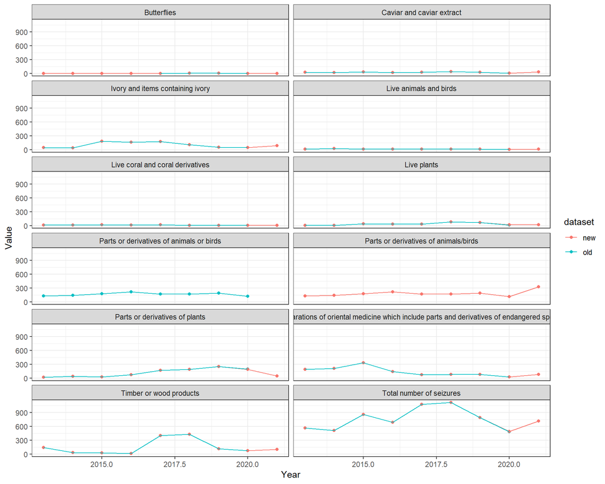

### Calculations

Q1, Q2, Q3, and Q4 were summed to give a total for each year.

The calculations used to create these figures was:

```
seizures_main_data_totals <- aggregate(x = seizures_main_data_totals[ , colnames(seizures_main_data_totals) != "Year"],
            by = list(seizures_main_data_totals$Year),
            FUN = sum)
```

Warning: This is copied from `update_15-7-1_and_15-c-1.R` and will not dynamically update if that code is changed.